# ESP106-Lab4

Veronica Herrera

February 6, 2023

## Lab 4

1. Boston: 8443970
2. New York: 8518750
3. Baltimore: 8574680
4. Charleston: 8665530
5. Miami: 8723214
6. Corpus Christi: 8775296

Before you start: add this file to your github repository, and commit your changes throughout the time you work on it.

### Part 1 - Monday

1. Create a data frame containing data on the city name and tide gauge ID

```r
install.packages("ggplot2", repos = "http://cran.us.r-project.org")
df <- data.frame (City = c("Boston","New York","Baltimore","Charleston","Miami","Corpus Christi"),
                  Tide_Guage_ID = c(8443970,8518750,8574680,8665530,8723214,8775296))
df
```

```
##             City Tide_Guage_ID
## 1         Boston       8443970
## 2       New York       8518750
## 3      Baltimore       8574680
## 4     Charleston       8665530
## 5          Miami       8723214
## 6 Corpus Christi       8775296
```

```r
print(df)
```

```
##             City Tide_Guage_ID
## 1         Boston       8443970
## 2       New York       8518750
## 3      Baltimore       8574680
## 4     Charleston       8665530
## 5          Miami       8723214
## 6 Corpus Christi       8775296
```

2a. Use a for-loop to read in the csv files and bind them together into a single data frame. Add a column to the data frame giving the name of the city the data is from.

```r
#Hint: you can use list.files() to get a vector of all the file names in a directory. Setting full.names=TRUE in the list.files() function will give you the full path name that can be used by read.csv

#Hint 2: you might want to create a data frame using the first csv file. Then loop through from files 2 to 6 reading in the csv file and using rbind() to attach it to the bottom of your full data frame

#Hint 3: It will be easiest to add the names of the city to the data frames immediately after reading them in, before binding everything together into a single data-frame


# Set working directory
getwd()
```

```
## [1] "C:/Users/verhe/Dropbox/VH UCD Geography MA/2022-2023/2_Winter/ESP 106/Lab 4"
```

```r
setwd('C:/Users/verhe/Dropbox/VH UCD Geography MA/2022-2023/2_Winter/ESP 106/Lab 4')
list.files(full.names=TRUE)
```

```
## [1] "./8443970.csv"              "./8518750.csv"
## [3] "./8574680.csv"              "./8665530.csv"
## [5] "./8723214.csv"              "./8775296.csv"
## [7] "./ESP106_week4.Rmd"         "./ESP106_week4_Herrera.Rmd"
```

```r
# get vector all file names in set working directory
# and read multiple files in a loop
files <- list.files(pattern = '\\.csv')


myfun = function(f) cbind(read.csv(f), Tide_Guage_ID=gsub(".csv", "", f))
tables <- lapply(files, myfun)

combined.df <- do.call(rbind,tables)
str(combined.df)
```

```
## 'data.frame':    658 obs. of  19 variables:
##  $ Year         : int  2011 2011 2011 2011 2011 2011 2011 2011 2011 2011 ...
##  $ Month        : int  1 2 3 4 5 6 7 8 9 10 ...
##  $ Highest      : num  0.844 0.686 0.695 0.658 0.719 0.659 0.519 0.49 0.73 0.739 ...
##  $ MHHW         : num  0.161 0.087 0.035 0.079 0.162 0.191 0.171 0.18 0.13 0.2 ...
##  $ MHW          : num  -0.003 -0.054 -0.083 -0.034 0.03 0.045 0.019 0.061 0.024 0.08 ...
##  $ MSL          : num  -1.45 -1.48 -1.5 -1.46 -1.37 ...
##  $ MTL          : num  -1.49 -1.52 -1.54 -1.5 -1.41 ...
##  $ MLW          : num  -2.97 -2.98 -3 -2.96 -2.85 ...
##  $ MLLW         : num  -3.07 -3.05 -3.06 -3.04 -2.96 ...
##  $ DTL          : num  -1.45 -1.48 -1.51 -1.48 -1.4 ...
##  $ GT           : num  3.23 3.14 3.1 3.12 3.12 ...
##  $ MN           : num  2.96 2.93 2.91 2.92 2.88 ...
##  $ DHQ          : num  0.164 0.141 0.117 0.113 0.132 0.146 0.152 0.119 0.106 0.12 ...
##  $ DLQ          : num  0.103 0.068 0.066 0.084 0.113 0.1 0.082 0.057 0.068 0.101 ...
##  $ HWI          : num  3.63 3.59 3.63 3.66 3.68 3.72 3.69 3.68 3.65 3.65 ...
##  $ LWI          : num  9.85 9.78 9.85 9.85 9.89 9.9 9.83 9.84 9.83 9.84 ...
##  $ Lowest       : num  -3.67 -3.7 -3.75 -3.76 -3.55 ...
##  $ Inferred     : int  0 0 0 0 0 0 0 0 0 0 ...
##  $ Tide_Guage_ID: chr  "8443970" "8443970" "8443970" "8443970" ...
```

```r
head(combined.df)
```

```
##   Year Month Highest  MHHW    MHW    MSL    MTL    MLW   MLLW    DTL    GT
## 1 2011     1   0.844 0.161 -0.003 -1.450 -1.485 -2.967 -3.070 -1.454 3.231
## 2 2011     2   0.686 0.087 -0.054 -1.483 -1.517 -2.981 -3.049 -1.481 3.136
## 3 2011     3   0.695 0.035 -0.083 -1.501 -1.539 -2.996 -3.062 -1.513 3.096
## 4 2011     4   0.658 0.079 -0.034 -1.456 -1.496 -2.958 -3.042 -1.481 3.121
## 5 2011     5   0.719 0.162  0.030 -1.372 -1.409 -2.849 -2.962 -1.400 3.124
## 6 2011     6   0.659 0.191  0.045 -1.357 -1.395 -2.836 -2.936 -1.372 3.127
##      MN   DHQ   DLQ  HWI  LWI Lowest Inferred Tide_Guage_ID
## 1 2.964 0.164 0.103 3.63 9.85 -3.671        0       8443970
## 2 2.927 0.141 0.068 3.59 9.78 -3.703        0       8443970
## 3 2.913 0.117 0.066 3.63 9.85 -3.749        0       8443970
## 4 2.924 0.113 0.084 3.66 9.85 -3.761        0       8443970
## 5 2.879 0.132 0.113 3.68 9.89 -3.549        0       8443970
## 6 2.881 0.146 0.100 3.72 9.90 -3.322        0       8443970
```

```r
# did not include city name column prior to bind, so used a left join using the
# merge()function to combine combined.df with my initial data frame (df)
# by "Tide_Guage_ID"

combined.df2 = merge(x=combined.df,y=df,by="Tide_Guage_ID",all.x=TRUE)
combined.df2
```

```
##     Tide_Guage_ID Year Month Highest   MHHW    MHW    MSL    MTL    MLW   MLLW
## 1         8443970 2011     1   0.844  0.161 -0.003 -1.450 -1.485 -2.967 -3.070
## 2         8443970 2011     2   0.686  0.087 -0.054 -1.483 -1.517 -2.981 -3.049
## 3         8443970 2011     3   0.695  0.035 -0.083 -1.501 -1.539 -2.996 -3.062
## 4         8443970 2011     4   0.658  0.079 -0.034 -1.456 -1.496 -2.958 -3.042
## 5         8443970 2011     5   0.719  0.162  0.030 -1.372 -1.409 -2.849 -2.962
## 6         8443970 2011     6   0.659  0.191  0.045 -1.357 -1.395 -2.836 -2.936
## 7         8443970 2011     7   0.519  0.171  0.019 -1.390 -1.434 -2.887 -2.969
## 8         8443970 2011     8   0.490  0.180  0.061 -1.371 -1.417 -2.895 -2.952
## 9         8443970 2011     9   0.730  0.130  0.024 -1.423 -1.458 -2.941 -3.009
## 10        8443970 2011    10   0.739  0.200  0.080 -1.356 -1.395 -2.871 -2.972
## 11        8443970 2011    11   0.753  0.083 -0.049 -1.473 -1.508 -2.968 -3.081
## 12        8443970 2011    12   0.683  0.014 -0.123 -1.510 -1.541 -2.960 -3.078
## 13        8443970 2012     1   0.763  0.029 -0.142 -1.534 -1.566 -2.991 -3.107
## 14        8443970 2012     2   0.395  0.019 -0.128 -1.532 -1.564 -3.001 -3.080
```

[output cut: 1303 more lines]

```r
# reordered column names through indexing so I can see City Name in the second column
# using the relocate()function from dplyr package (purely for aesthetic purposes,
# I couldn't stand its default location X_X )


install.packages("dplyr",repos = "http://cran.us.r-project.org")
library(dplyr)
combined.df3 <- combined.df2 %>%
  relocate(City,.before=Year)
combined.df3
```

```
##     Tide_Guage_ID           City Year Month Highest   MHHW    MHW    MSL    MTL
## 1         8443970         Boston 2011     1   0.844  0.161 -0.003 -1.450 -1.485
## 2         8443970         Boston 2011     2   0.686  0.087 -0.054 -1.483 -1.517
## 3         8443970         Boston 2011     3   0.695  0.035 -0.083 -1.501 -1.539
## 4         8443970         Boston 2011     4   0.658  0.079 -0.034 -1.456 -1.496
## 5         8443970         Boston 2011     5   0.719  0.162  0.030 -1.372 -1.409
## 6         8443970         Boston 2011     6   0.659  0.191  0.045 -1.357 -1.395
## 7         8443970         Boston 2011     7   0.519  0.171  0.019 -1.390 -1.434
## 8         8443970         Boston 2011     8   0.490  0.180  0.061 -1.371 -1.417
## 9         8443970         Boston 2011     9   0.730  0.130  0.024 -1.423 -1.458
## 10        8443970         Boston 2011    10   0.739  0.200  0.080 -1.356 -1.395
## 11        8443970         Boston 2011    11   0.753  0.083 -0.049 -1.473 -1.508
## 12        8443970         Boston 2011    12   0.683  0.014 -0.123 -1.510 -1.541
## 13        8443970         Boston 2012     1   0.763  0.029 -0.142 -1.534 -1.566
## 14        8443970         Boston 2012     2   0.395  0.019 -0.128 -1.532 -1.564
```

[output cut: 1303 more lines]

2b. Take a look at your data frame - is this in a tidy format?

```r
#Yes it is. The combined.df3 data frame because observations are represented as rows,
# variables are represented as columns, and each value of a variable is stored in a cell of the table,
# one type of observational unit per table.
```

We are going to examine the question of whether these gauges show evidence of rising sea levels. One of the first things we have to deal with is the issue of dates.

Your data frame right now has one column with a year and one with the month. We are going to combine these into a single column, and use as.Date to formally use Date objects

3a. Create a new column named “Date” that has the first day of the month for that row in the format YYYY-MM-01 where YYYY is the data in the Year column and MM is the data in the Month column.

```r
#Hint: Use paste0() to combine data and characters (i.e. the required separators "-")

combined.df3$Date <- paste0(combined.df3$Year,sep ='-',combined.df3$Month,sep ='-','1')
print(combined.df3)
```

```
##     Tide_Guage_ID           City Year Month Highest   MHHW    MHW    MSL    MTL
## 1         8443970         Boston 2011     1   0.844  0.161 -0.003 -1.450 -1.485
## 2         8443970         Boston 2011     2   0.686  0.087 -0.054 -1.483 -1.517
## 3         8443970         Boston 2011     3   0.695  0.035 -0.083 -1.501 -1.539
## 4         8443970         Boston 2011     4   0.658  0.079 -0.034 -1.456 -1.496
## 5         8443970         Boston 2011     5   0.719  0.162  0.030 -1.372 -1.409
## 6         8443970         Boston 2011     6   0.659  0.191  0.045 -1.357 -1.395
## 7         8443970         Boston 2011     7   0.519  0.171  0.019 -1.390 -1.434
## 8         8443970         Boston 2011     8   0.490  0.180  0.061 -1.371 -1.417
## 9         8443970         Boston 2011     9   0.730  0.130  0.024 -1.423 -1.458
## 10        8443970         Boston 2011    10   0.739  0.200  0.080 -1.356 -1.395
## 11        8443970         Boston 2011    11   0.753  0.083 -0.049 -1.473 -1.508
## 12        8443970         Boston 2011    12   0.683  0.014 -0.123 -1.510 -1.541
## 13        8443970         Boston 2012     1   0.763  0.029 -0.142 -1.534 -1.566
## 14        8443970         Boston 2012     2   0.395  0.019 -0.128 -1.532 -1.564
```

[output cut: 1962 more lines]

3b. Use as.Date to convert your new date column to a date object in R

```r
# column is currently a "character" data type, or as shown in the printed data results
class(combined.df3$Date)
```

```
## [1] "character"
```

```r
# Created new column to data frame using the $ operator
combined.df3$Date <- as.Date(combined.df3$Date)

# Date variable now has a Date data type.
# verification #1
print(combined.df3)
```

```
##     Tide_Guage_ID           City Year Month Highest   MHHW    MHW    MSL    MTL
## 1         8443970         Boston 2011     1   0.844  0.161 -0.003 -1.450 -1.485
## 2         8443970         Boston 2011     2   0.686  0.087 -0.054 -1.483 -1.517
## 3         8443970         Boston 2011     3   0.695  0.035 -0.083 -1.501 -1.539
## 4         8443970         Boston 2011     4   0.658  0.079 -0.034 -1.456 -1.496
## 5         8443970         Boston 2011     5   0.719  0.162  0.030 -1.372 -1.409
## 6         8443970         Boston 2011     6   0.659  0.191  0.045 -1.357 -1.395
## 7         8443970         Boston 2011     7   0.519  0.171  0.019 -1.390 -1.434
## 8         8443970         Boston 2011     8   0.490  0.180  0.061 -1.371 -1.417
## 9         8443970         Boston 2011     9   0.730  0.130  0.024 -1.423 -1.458
## 10        8443970         Boston 2011    10   0.739  0.200  0.080 -1.356 -1.395
## 11        8443970         Boston 2011    11   0.753  0.083 -0.049 -1.473 -1.508
## 12        8443970         Boston 2011    12   0.683  0.014 -0.123 -1.510 -1.541
## 13        8443970         Boston 2012     1   0.763  0.029 -0.142 -1.534 -1.566
## 14        8443970         Boston 2012     2   0.395  0.019 -0.128 -1.532 -1.564
```

[output cut: 1962 more lines]

```r
# verification #2
class(combined.df3$Date)
```

```
## [1] "Date"
```

```r
# changed location of Date column after Month and updated data frame
# to reflect changes
combined.df3 <- combined.df3 %>% relocate(Date,.after=Month)
combined.df3
```

```
##     Tide_Guage_ID           City Year Month       Date Highest   MHHW    MHW
## 1         8443970         Boston 2011     1 2011-01-01   0.844  0.161 -0.003
## 2         8443970         Boston 2011     2 2011-02-01   0.686  0.087 -0.054
## 3         8443970         Boston 2011     3 2011-03-01   0.695  0.035 -0.083
## 4         8443970         Boston 2011     4 2011-04-01   0.658  0.079 -0.034
## 5         8443970         Boston 2011     5 2011-05-01   0.719  0.162  0.030
## 6         8443970         Boston 2011     6 2011-06-01   0.659  0.191  0.045
## 7         8443970         Boston 2011     7 2011-07-01   0.519  0.171  0.019
## 8         8443970         Boston 2011     8 2011-08-01   0.490  0.180  0.061
## 9         8443970         Boston 2011     9 2011-09-01   0.730  0.130  0.024
## 10        8443970         Boston 2011    10 2011-10-01   0.739  0.200  0.080
## 11        8443970         Boston 2011    11 2011-11-01   0.753  0.083 -0.049
## 12        8443970         Boston 2011    12 2011-12-01   0.683  0.014 -0.123
## 13        8443970         Boston 2012     1 2012-01-01   0.763  0.029 -0.142
## 14        8443970         Boston 2012     2 2012-02-01   0.395  0.019 -0.128
```

[output cut: 1962 more lines]

Now lets use ggplot to make some cool graphs of this data using ggplot.

4. Make a plot showing data from all 6 gauges on the same plot. Use different colors to distinguish lines for the different cities. See the example plot uploaded to Canvas (Plot 1)
- Plot the date on the x axis and MHHW (mean higher high water - i.e. the average daily high water level) on the y axis Make sure to add proper axis labes and units (using +labs(x=““,y=”“))
- Add a single best-fit line through the full data set using geom_smooth(method=“lm”) - note that by default ggplot will fit one best fit line for each city. To override this specify the aestetic mapping (aes()) again within the geom_smooth function and add the argument inherit.aes=FALSE

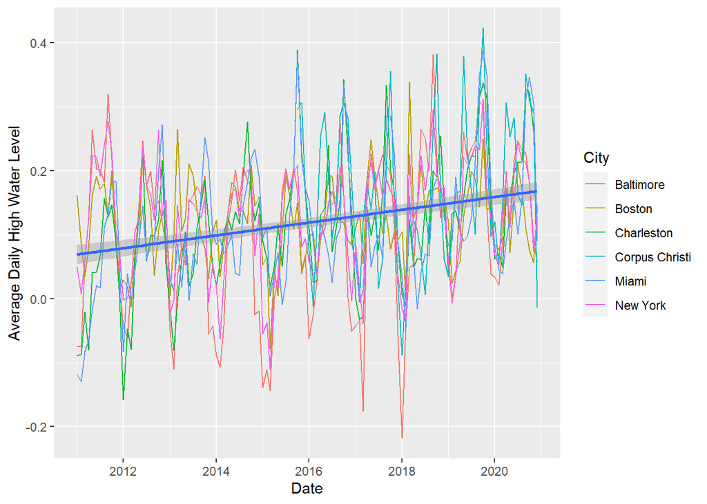

```r
#if you don't already have ggplot2 then install it with install.packages("ggplot2")
# Date = X
# Average daily high water level = Y

library(ggplot2)

ggplot(combined.df3,aes(Date,
                        MHHW,
                        col=City))+
  geom_line()+
  labs(x='Date',y='Average Daily High Water Level')+
  geom_smooth(method="lm",aes(x=Date,y=MHHW),inherit.aes=FALSE)
```

5. Now make a slightly different plot with the same x and y variables, but use facet_wrap() to make a subplot separately for each city. Add a best-fit line for each subplot. See the example plot uploaded to Canvas (Plot 2)

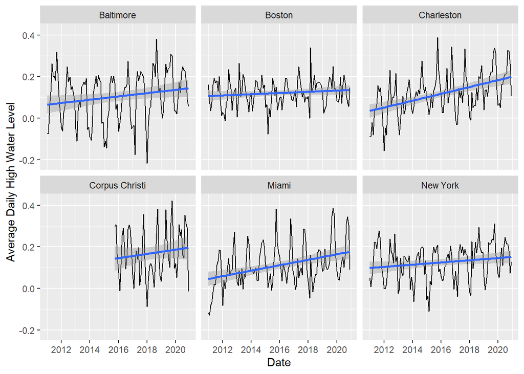

```r
#Hint: you should only need minor modification of the code from question 4 to make this plot



# Used facet wrap to make ribbon of panels for a single variable "City"
ggplot(combined.df3,aes(Date,
                        MHHW))+
  geom_line()+
  labs(x='Date',y='Average Daily High Water Level')+
  geom_smooth(method="lm",aes(x=Date,y=MHHW),inherit.aes=FALSE)+
  facet_wrap(~City)
```

### Part 2 - Wednesday

In this part of the lab we will identify some outliers, and practice running regressions

6. Make a box plot showing the distribution of the highest tides each month (“Highest” column in the NOAA data) . (Ideally practice using ggplot by using geom_boxplot() - put the city on the x axis and Highest on the y. But this can also be done in base R). See the example plot on Canvas (Plot 3)

```r
# City = x
# Highest = y

# Theme or plot background set up
theme_bw=theme(panel.background=element_rect(fill="white",color="black"),
               panel.grid.major = element_line(color="gray88",linetype = "solid" ),
               panel.grid.minor = element_line(color= "gray88",linewidth = 0.5))
print(theme_bw)
```

```
## List of 3
##  $ panel.background:List of 5
##   ..$ fill         : chr "white"
##   ..$ colour       : chr "black"
##   ..$ linewidth    : NULL
##   ..$ linetype     : NULL
##   ..$ inherit.blank: logi FALSE
##   ..- attr(*, "class")= chr [1:2] "element_rect" "element"
##  $ panel.grid.major:List of 6
##   ..$ colour       : chr "gray88"
##   ..$ linewidth    : NULL
##   ..$ linetype     : chr "solid"
##   ..$ lineend      : NULL
##   ..$ arrow        : logi FALSE
##   ..$ inherit.blank: logi FALSE
##   ..- attr(*, "class")= chr [1:2] "element_line" "element"
##  $ panel.grid.minor:List of 6
##   ..$ colour       : chr "gray88"
##   ..$ linewidth    : num 0.5
##   ..$ linetype     : NULL
##   ..$ lineend      : NULL
##   ..$ arrow        : logi FALSE
##   ..$ inherit.blank: logi FALSE
##   ..- attr(*, "class")= chr [1:2] "element_line" "element"
##  - attr(*, "class")= chr [1:2] "theme" "gg"
##  - attr(*, "complete")= logi FALSE
##  - attr(*, "validate")= logi TRUE
```

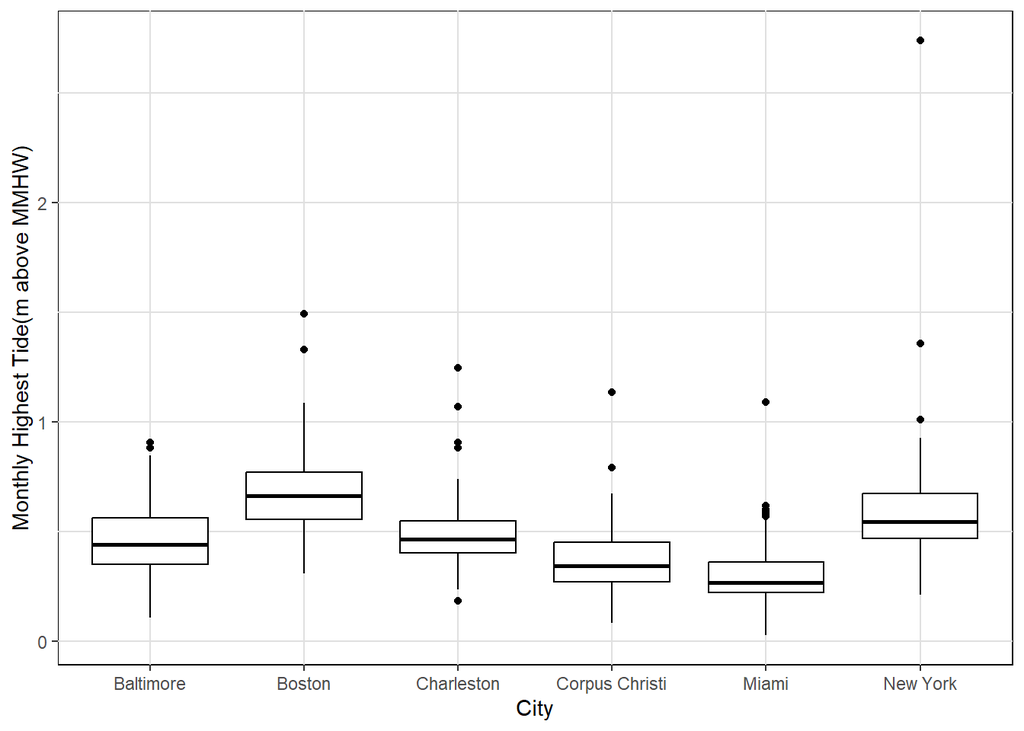

```r
# Plotting
ggplot(combined.df3,aes(City,
                        Highest,
                        col=City))+
  geom_boxplot(color="black",outlier.core="black")+
  labs(x='City',y="Monthly Highest Tide(m above MMHW)")+
  theme_bw
```

Notice the very extreme value in New York City - a major outlier both within New York and compared to all the other cities

7a. Find the row in the data corresponding to this outlier observation

```r
#Hint: The which.max() function might be useful here

combined.df3[which.max(combined.df3$Highest),]
```

```
##     Tide_Guage_ID     City Year Month       Date Highest  MHHW   MHW    MSL
## 141       8518750 New York 2012    10 2012-10-01   2.739 0.263 0.145 -0.555
##        MTL    MLW   MLLW    DTL    GT    MN   DHQ   DLQ  HWI  LWI Lowest
## 141 -0.587 -1.318 -1.384 -0.561 1.647 1.463 0.118 0.066 0.81 7.23 -1.842
##     Inferred
## 141        0
```

7b. What month and year did this outlier event occur in? What meteorological event happened in New York in that month that probably caused this outlier event? (Feel free to use Google - I don’t expect you to know this off hand)

```r
# Month = 10 (October)
# Year = 2012
# Event: Hurricane Sandy in New York City on October 29, 2012.
```

Finally, we will fit a linear model to estimate the rate of sea-level rise across these 6 cities.

8a. Fit a linear regression with the mean higher high water (MHHW) as the dependent variable and date (i.e. time) as the independent variable.

```r
#Hint: the forumla in your lm() function is of the form y~x where y here is MHHW and x is your date column

LRM <- lm(MHHW~Date,data=combined.df3)
  class(LRM)
```

```
## [1] "lm"
```

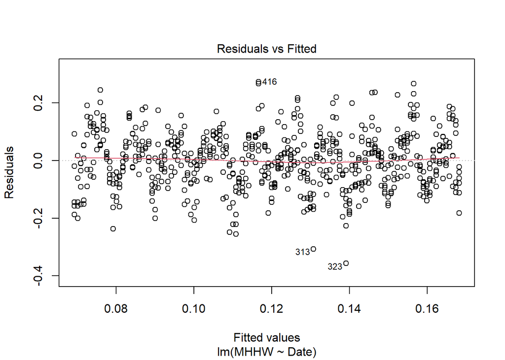

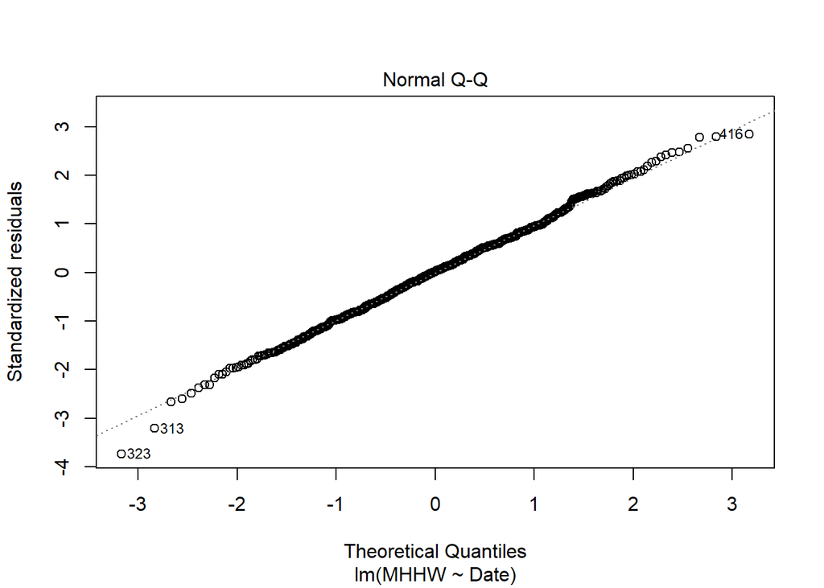

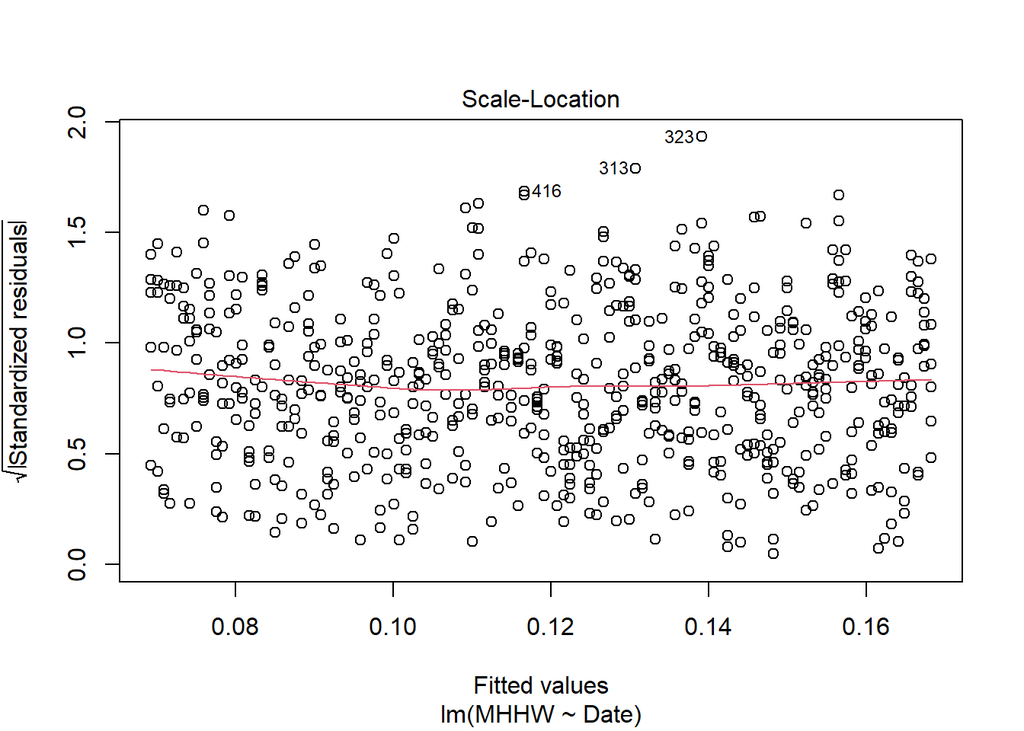

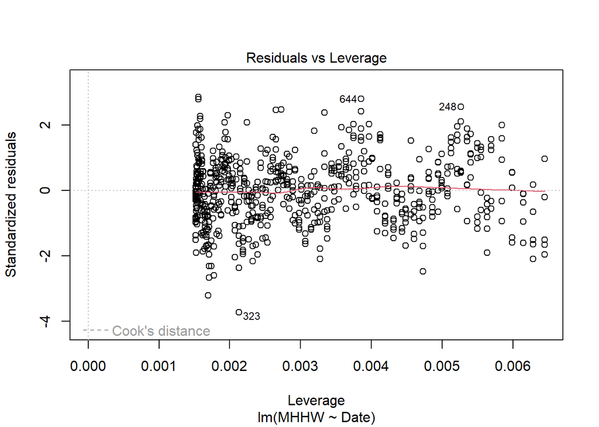

```r
  plot(LRM)
```

8b. Give the estimated coefficient of the date column. Is it statistically significant (i.e. has a p-value less than 0.05)?

This coefficient gives us the average increase in high tide levels each day, across all six cities, for this ten year time frame (i.e. the units of the coefficient are in m per day).

```r
summary(LRM)$coefficients
```

```
##                  Estimate   Std. Error   t value     Pr(>|t|)
## (Intercept) -3.398793e-01 6.002228e-02 -5.662553 2.231680e-08
## Date         2.732001e-05 3.551610e-06  7.692288 5.313671e-14
```

```r
# estimated coefficient 2.732001e-05 indicates it is statistically significant
```

8c. Using your estimated coefficient, estimate the mean increase in sea-level over the 10 year time frame from 2011-2020.

```r
m <- (2.732*10^-05*(365*10)+(-3.399*10^-01))-(2.732*10^-05*1+(-3.399*10^-01))
m/10
```

```
## [1] 0.009969068
```

Upload your .Rmd file and you knitted file with the answers and plots to Canvas

##STRETCH GOAL

If you are looking for a challenge, have a go downloading the original csv files directly from the NOAA API. Details on the API are here: https://api.tidesandcurrents.noaa.gov/api/prod/

You will want to paste together a URL describing the data you want from the API, then use download.file() to download the data from that URL into a directory on your computer.

The URL you want will have the following form, except you will loop through to replace *GAUGEID* with each of the six tide gauge ID numbers:

paste0(“https://api.tidesandcurrents.noaa.gov/api/prod/datagetter?begin_date=20110101&end_date=20201231&station=”,*GAUGEID*,“&product=monthly_mean&datum=MHHW&units=metric&time_zone=lst&format=csv”)

See if you can make sense of this URL given the options listed at the website describing access to the API